# Feature Optimization for Coffee Adulteration Detection Using Hyperspectral Imaging and Linear Discriminant Analysis (LDA): Genetic Algorithm Using Raw Spectra Data

Author

Derick Malavi

## Introduction

This project utilizes **Linear Discriminant Analysis (LDA)** to assess its effectiveness in distinguishing authentic coffee from adulterated samples based on spectral data. As a classical statistical method, LDA identifies linear boundaries that maximize class separation, making it particularly well-suited for high-dimensional spectroscopic datasets. This study demonstrates the capability of LDA to accurately classify pure and adulterated coffee, showcasing its potential as a reliable tool for detecting and quantifying coffee adulteration.

To enhance model performance and interpretability, feature selection techniques such as **Recursive Feature Elimination (RFE)** and **Genetic Algorithms (GA)** are employed. These methods aim to identify the most relevant spectral features, reducing dimensionality while preserving classification accuracy.

```r
# Load libraries
warning = FALSE
  suppressWarnings(suppressMessages({
  library(caret)
  library(GA)
  library(ggplot2)
  library(dplyr)
  library(readxl)
  library(readr)
  library(pls)
  library(janitor)
  library(class)
  library(MLmetrics)
  library(MLeval)
  library(themis)
  library(NeuralNetTools)
  library(ROSE)
  library(parallel)
  library(doParallel)
  library(foreach)
  library(pheatmap)
  library(mdatools)
  library(DMwR)
  library(e1071)
  library(knitr)
  library(pROC)
  library(gridExtra)
  library(FactoMineR)
  library(doSNOW)
  library(MASS)
  library(factoextra)
  library(DMwR)
  library(kernlab)}))
```

## Prepare Data

```r
# Load data: raw spectra

hsi_raw <- read.csv("instant_coffee_raw.csv")

# Ensure we have the same number of dimensions and the range of our columns
dim(hsi_raw)
```

```
[1] 1476  229
```

```r
# Check a few column names
col_check <- colnames(hsi_raw[,c(1:6)])
col_check
```

```
[1] "sample_name"  "binary_class" "three_class"  "cal_val"      "perc_adulter"
[6] "X935.609985"
```

```r
# The spectral values start from column # 6-------> 229

# Convert the class to a factor
hsi_raw$binary_class <- as.factor(hsi_raw$binary_class)
```

## Get the X and y variables

```r
X <- hsi_raw[,c(6:229)]
y <- hsi_raw[,2]

class(y) #Ensure y (target variable) is a factor for classification
```

```
[1] "factor"
```

## Visualize X

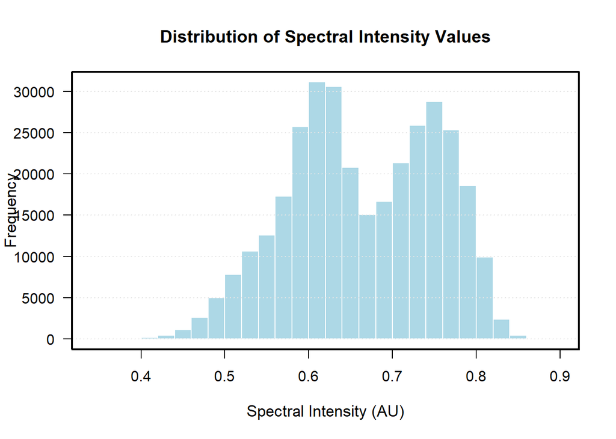

```r
# Create histogram of spectral intensities with improved formatting
hist(as.matrix(X),
     col = "lightblue",
     border = "white",
     main = "Distribution of Spectral Intensity Values",
     xlab = "Spectral Intensity (AU)",
     ylab = "Frequency",
     las = 1,
     cex.main = 1.2,
     cex.lab = 1.1,
     breaks = 30)

# Add grid lines
grid(nx = NA, ny = NULL, col = "gray90", lty = "dotted")

# Add box around plot
box(lwd = 2)
```